# Endogeneity

## Exogeneity

We will continue to show how we can weaken the assumptions of the linear regression model

Now, we’re going to tackle Assumption 2, the mean-zero errors assumption

This assumption is also known as **exogeneity**

Recall that this assumption holds that, conditional on all of the $x$’s, $E(\varepsilon_i)=0$

Also recall that we said that the real assumption here is that the mean of $\varepsilon$ doesn’t depend on those $x$’s

In fact, we can restate this assumption as $Cov(\varepsilon_i, x)=0$ (assuming a univariate regression for simplicity)

Now, we’ll investigate the consequences of failures of this assumption

For simplicity, we’ll do our analysis in the context of a univariate regression, but our conclusions will carry over to the multivariate case

## Endogeneity

**Endogeneity** is when exogeneity does *not* hold, so that $Cov(x, \varepsilon) \ne 0$

As we will see, the consequences of endogeneity are much more severe than was the case for heteroskedasticity or autocorrelation

The reason for this was that we used the assumption of *exogeneity* when we proved that OLS is unbiased and consistent

Therefore, *endogeneity* will mean that our regressions are not good estimates of the population regression coefficients that we want to know

There are several reasons why we might have endogeneity

**1. Omitted-variable bias.** One case we’ve already talked about is when there is omitted-variable bias

Suppose that the true model is

$$y = \alpha + \beta_1 x_1 + \beta_2 x_2 + u$$

If we exclude $x_2$ from the regression, then we can write the model as

$$y = \alpha + \beta_1 x_1 + (\beta_2 x_2 + u)
= \alpha + \beta_1 x_1 + \varepsilon$$

If $x_2$ is correlated with $x_1$, then $\varepsilon$ will be as well

We already know that the expectation of the coefficient on $x_1$ from a model that excludes $x_2$ is

$$E(b) = \beta_1 + \beta_2 b_{x_2 x_1}$$

where $b_{x_2 x_1}$ is the slope coefficient from a regression of $x_2$ on $x_1$

If $x_2$ and $x_1$ are correlated, $b_{x_2 x_1} \ne 0$

Hence, OLS will be biased (and also inconsistent)

**2. Simultaneity/reverse causality.** Suppose that the demand curve is given by

$$Q = a - bP + e$$

and the supply curve is

$$Q = c + dP + u$$
Now suppose that you have data on on prices and quantities from multiple market equilibira (say, from one market over time, or across different markets)

**Question:** Does a regression of $Q$ on $P$ tell you the demand curve or the supply curve?

Every econ 202 student knows that, in equilibrium, $Q^D = Q^S$, which implies that the equilibrium price satisfies

$$P^* = \frac{c - a + u - e}{d - b}$$

But this is a function of the error terms in both the supply and demand curves

Regardless of whether we’re trying to estimate supply or demand, the price will be endogeneous

**Answer:** A regression of $Q$ on $P$ doesn’t tell us the supply curve or the demand curve

This is best understood graphically

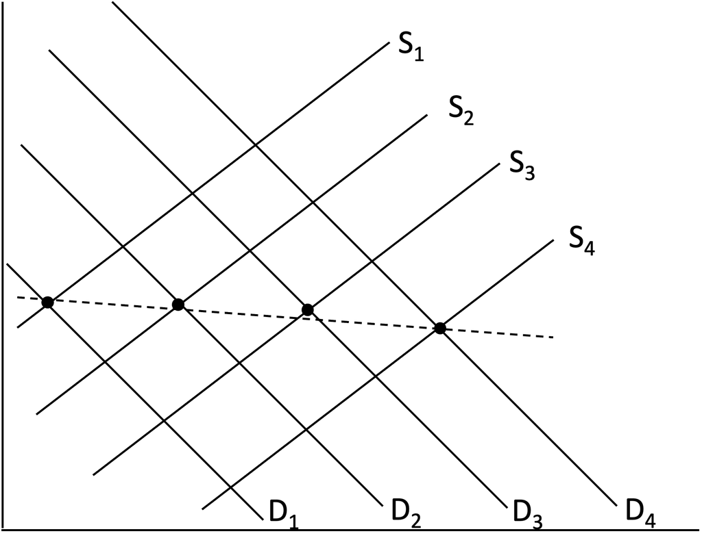

Since $P$ is endogenous, OLS doesn’t tell us supply or demand

## Consequences of endogeneity

We’ve already seen intuition for, and examples of, the consequences of endogeneity, but let’s take a more formal look

Recall from our discussion of the properties of regression that (assuming deviations from means form)

$$b = \beta + \frac{\sum x_i \varepsilon_i}{\sum x_i^2}$$

Therefore,

$$\begin{aligned}
E(b) &= \beta + E\left( \frac{\sum x_i \varepsilon_i}{\sum x_i^2} \right) \\
&= \beta + \frac{\sum_i x_i E(\varepsilon_i).}{\sum_i x_i^2}
\end{aligned}$$

When exogeneity held, this last term vanished, so that $b$ was unbiased

Under endogeneity, it won’t, so $b$ is biased. Since $Var(b) \to 0$ as $n$ grows, this also implies that $b$ is inconsistent

## Two-stage least squares/instrumental variables

What can we do about endogeneity?

If the endogeneity arises because of omitted variables, one solution is to simply include the omitted variables

But we might not have data on an important variable that we think is omitted

For example, suppose that our model is

$$wage = \alpha + \beta_1 educ + \varepsilon,$$

and we’re worried that ambition, which might be correlated with education, is an omitted variable

It could be very difficult to find a dataset that includes any reasonable measure of a person’s ambition

Now suppose that we’re worried about endogeneity due to simultaneity

In this case, the endogeneity is really caused by the fact that $P$ and $Q$ are determined in equilibrium by the intersection of supply and demand

In this case, the endogeneity doesn’t really arise because of an omitted variable, so it’s not obvious that we can solve it by just controlling for additional variables

**Two-stage least squares** is one solution to this problem

Suppose that we have an **instrumental variable** $z$ that satisfies the following conditions:

1. **Exogeneity:** $Cov(z, \varepsilon) = 0$, and
2. **Relevance:** $Cov(z, x) \ne 0$

In other words, $z$ is correlated with $x$ but, unlike $x$, $z$ is not correlated with $\varepsilon$

Instrumental variables are sometimes called **natural experiments,** because it is as if $z$ is randomly changing $x$ without having any other effect on $y$

We summarize this by saying “$z$ only affects $y$ *through* $x$”

Now consider the following **instrumental variables** or **two-stage least squares** procedure:

1. Regress $x$ on $z$ to obtain the predicted values $\widehat{x}$
2. Regress $y$ on $\widehat{x}$

Why would we do this?

The predicted value of $\widehat{x}$ is clearly related to $x$

But since the prediction is based on $z$ (which is uncorrelated with $\varepsilon$), $\widehat{x}$ is also uncorrelated with $\varepsilon$

We can think of $\widehat{x}$ as “the part of $x$ that is uncorrelated with $\varepsilon$”

## Properties of IV/2SLS

If you suspect that regresing $y$ on $\widehat{x}$ (instead of $x$ itself) will produce a good estimate of $\beta$, you’re right

To show this, let’s go back to deviations-from-means form, in which case our regressions don’t need constant terms

In this case, we can write our predicted value of $x$ as

$$\widehat{x}_i = d*z_i,$$
where $d$ is the coefficient from a regresion of $x$ on $z$

The two-stage least squares estimate of $\beta$ is just the coefficient from a regression of $y$ on $\widehat{x}$, or

$$b^{IV}= \frac{\sum_i \widehat{x}_i y_i}{\sum_i \widehat{x}_i^2}
= \frac{\sum_i dz_i y_i}{\sum_i (dz_i)^2}
= \frac{d\sum_i z_i y_i}{d \sum_i d z_i^2}
= \frac{\sum_i z_i y_i}{\sum_i (d z_i) z_i}$$

We can write $x_i = dz_i + f_i$, where $f_i$ is the residual from regressing $x$ on $z$

From our discussion of residual properties, we also know that $\sum_i z_i f_i = 0$, so we can add this to the last line:

$$b^{IV} = \frac{\sum_i z_i y_i}{\sum_i [(dz_i)z_i + z_i f_i]}
= \frac{\sum_i z_i y_i}{\sum_i (dz_i + f)z_i}
= \frac{\sum_i z_i y_i}{\sum_i x_i z_i}$$

Now, let’s use the fact that we don’t need a constant in deviations-from-means form to write

$$y_i = \beta x_i + \varepsilon_i$$

Plugging in,

$$\begin{aligned}
b^{IV} &= \frac{\sum_i z_i y_i}{\sum_i x_i z_i}
= \frac{\sum_i z_i (x_i \beta + \varepsilon_i) }{\sum_i x_i z_i}
= \frac{\beta\sum_i z_i x_i }{\sum_i x_i z_i}
+ \frac{\sum_i z_i \varepsilon_i}{\sum_i x_i z_i} \\
&= \beta + \frac{\sum_i z_i \varepsilon_i}{\sum_i x_i z_i}
\end{aligned}$$

This is the home stretch

Rewrite $b^{IV}$ as

$$b^{IV} = \beta + \frac{\sum_i z_i \varepsilon_i}{\sum_i x_i z_i}
= \beta + \frac{\frac{1}{n}\sum_i z_i \varepsilon_i}{\frac{1}{n}\sum_i x_i z_i}$$

and recall that the **Law of large numbers** says that sample means converge to populations means as $n$ grows, so

$$b^{IV} \to \beta + \frac{E(z_i \varepsilon_i)}{E(z_i x_i)}$$

$$b^{IV} \to \beta + \frac{E(z_i \varepsilon_i)}{E(z_i x_i)}$$

But in deviations-from-means form,

$$Cov(z_i, \varepsilon_i) = E\{ [z_i - E(z_i)] [\varepsilon_i - E(\varepsilon_i)] \}
= E(z_i \varepsilon_i),$$

so the second term is zero, and $b^{IV} \to \beta$

This shows that IV/2SLS is **consistent**

Finishing up the properties of IV/2SLS, an argument similar to the one we used for OLS (I’ll spare you the derivation) shows that (no longer assuming deviations-from-means form)

$$V(b^{IV}) \approx \frac{\sigma^2 \sum_i (z_i - \bar{z})^2}
{\sum_i (z_i - \bar z)(x_i - \bar x)}$$

We can estimate $\sigma^2$ using

$$s^2_{IV} = \frac{\sum_i e_i^2}{n-2}
= \frac{\sum_i (y_i - a^{IV} - b^{IV} x_i)}{n-2}$$

Let’s do a simulation to see how well this works. We can use the `ivreg` package to do IV regressions in R:

```r
library(tidyverse)
library(ivreg)
b <- rep(0,1000)
b.iv <- b
for (i in 1:1000) {
  z <- rnorm(1000)
  u <- rnorm(1000)
  x <- .5*z + .25*u + rnorm(1000) # x deps on z and u
  e <- u + rnorm(1000) # e deps on u
  y <- 1 + 2*x + e
  b[i] <- lm(y ~ x)$coef[2]
  b.iv[i] <- ivreg(y ~ x | z)$coefficients[2]
}
bs <- data.frame(b=c(b, b.iv))
bs$est <- factor(c(rep("ols", 1000), rep("iv",1000)), level=c("ols", "iv"))
```

```r
ggplot(bs, aes(b)) + geom_histogram() + facet_wrap("factor(est)") + geom_vline(xintercept=2)
```

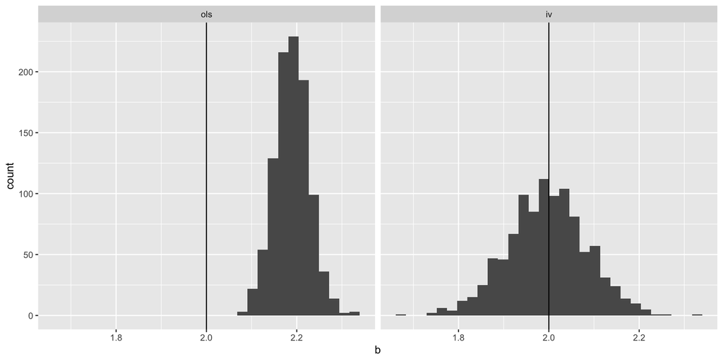

## “IV” vs. “2SLS”

We have been using the terms IV and 2SLS interchangeably

When there is one IV per endogeneous variable, IV and 2SLS are the same

However, we can also use our procedure when we have more IVs than endogenous variables

To do this, we obtain $\widehat{x}$ by regressing $x$ on *all* of the IVs

In this case, the term “2SLS” is more appropriate

## Multivariate IV/2SLS

IV/2SLS carry over to the multivariate case with very little change

Suppose that our model is

$$y = \alpha + \beta_1 x_1 + \beta_2 x_2 + \varepsilon,$$

where we’re worried that $x_1$ is endogenous, but we have an IV $z_1$

We can do IV/2SLS by regressing $x_1$ on $z_1$ *and* $x_2$ to obtain $\widehat{x}_1$

If we also thought that $x_2$ were endogenous, we’d need an additional IV for that variable

## “Manual” vs “canned” IV/2SLS

Although we can implement our two-stage procedure manually, it’s better to use a pre-programmed IV/2SLS function

The reason for this is that when we do 2SLS manually, our software tries to estimate $\varepsilon$ as $e_i = y_i - b^{IV} \widehat{x}_i$, when what we really want is $y_i - b^{IV} x_i$ (i.e., using the *real*, rather than predicted, $x$)

A pre-programmed IV function will handle this automatically

Let’s illustrate this:

```r
z <- rnorm(1000)
u <- rnorm(1000)
x <- .5*z + .25*u + rnorm(1000) # x deps on z and u
e <- u + rnorm(1000) # e deps on u
y <- 1 + 2*x + e
x.hat <- lm(x ~ z)$fitted.values
summary(lm(y ~ x.hat))
```

```
Call:
lm(formula = y ~ x.hat)

Residuals:
    Min      1Q  Median      3Q     Max
-8.3992 -1.8324  0.0917  1.9246  9.5933

Coefficients:
            Estimate Std. Error t value Pr(>|t|)
(Intercept)  0.97986    0.08624   11.36   <2e-16 ***
x.hat        1.85058    0.16677   11.10   <2e-16 ***
---
Signif. codes:  0 '***' 0.001 '**' 0.01 '*' 0.05 '.' 0.1 ' ' 1

Residual standard error: 2.726 on 998 degrees of freedom
Multiple R-squared:  0.1098,    Adjusted R-squared:  0.1089
F-statistic: 123.1 on 1 and 998 DF,  p-value: < 2.2e-16
```

```r
summary(ivreg(y ~ x | z))
```

```
Call:
ivreg(formula = y ~ x | z)

Residuals:
     Min       1Q   Median       3Q      Max
-4.46357 -0.96297  0.01422  0.95584  5.25118

Coefficients:
            Estimate Std. Error t value Pr(>|t|)
(Intercept)  0.97986    0.04451   22.02   <2e-16 ***
x            1.85058    0.08608   21.50   <2e-16 ***

Diagnostic tests:
                 df1 df2 statistic  p-value
Weak instruments   1 998    251.43  < 2e-16 ***
Wu-Hausman         1 997     25.82 4.48e-07 ***
Sargan             0  NA        NA       NA
---
Signif. codes:  0 '***' 0.001 '**' 0.01 '*' 0.05 '.' 0.1 ' ' 1

Residual standard error: 1.407 on 998 degrees of freedom
Multiple R-Squared: 0.7629, Adjusted R-squared: 0.7626
Wald test: 462.2 on 1 and 998 DF,  p-value: < 2.2e-16
```

## First-stage regression

Remmeber, a *valid* IV satisifes two properties

1. **Exogeneity:** $Cov(z, \varepsilon)=0$, and
2. **Relevance:** $Cov(z, x) \ne 0$

Since we don’t have data on $\varepsilon$, we can’t really test exogeneity<sup>1</sup>

[^1]: Technically, there are some roundabout ways to test this, but they make strong assumptions

However, we *can and should* test the relevance of the instrument

To do this, we can examine the **first-stage** regression of $x$ on the instruments to see if they are statistically significant

In the multivariate case, the best way to do this is using the F-test for the joint significance of all of the regressors (i.e., the null hypothesis that the coefficient on *all* of the variables we used to predict $x$ are zero)

## “Weak instruments”

You may have noticed that we proved that $b^{IV}$ is consistent, but didn’t say anything about unbiasedness

This is because IV is *not* unbiased<sup>1</sup>

So consistency is the best we can do, but this is ok — consistency is a good property for an estimator to have

[^2]: In fact, in many cases, the population mean of $b^{IV}$ doesn’t even exist!

It turns out that IV tends to be more biased when the correlation between $x$ and $z$ is small (this is known as a **weak instrument**)

Intuitively, this is because our prediction $\widehat{x}$ is based on an estimate of the relationship between $x$ and $z$ and not the *true* relationship, so in small samples, $\widehat{x}$ is not completely uncorrelated with $\varepsilon$

A common rule of thumb is that if the F-statistic from the **first-stage regression** of $x$ on the instruments is greater than 10, the bias won’t be too bad

There are a couple of other bad things that can happen when your instrument is weak

First, the standard errors might be large

Recall that the variance of the IV slope coefficient is

$$V(b^{IV}) \approx \frac{\sigma^2 \sum_i (z_i - \bar{z})^2}
{\sum_i (z_i - \bar z)(x_i - \bar x)}$$

The denominator is essentially the sample covariance between $z$ and $x$—when this is low, $V(b^{IV})$ will be large

We care about this because when the SEs are large, we might not be able to reject null hypotheses, even when they’re actually false

The second problem is that if the instrument actually turns out to be *endogenous*, IV can be *more biased* than OLS

To see this, recall that we previously showed that
$$\begin{aligned}
b &= \beta + \frac{\sum_i x_i \varepsilon_i}{\sum_i x_i^2}
\to \beta + \frac{Cov(x, \varepsilon)}{Var(x)} \\
b^{IV} &= \beta + \frac{\sum_i z_i \varepsilon_i}{\sum_i x_i z_i}
\to \beta + \frac{Cov(z, \varepsilon)}{Cov(x, z)} \\
\end{aligned}$$
When the instrument is weak, a small amount of covariance between $z$ and $\varepsilon$ gets divided by a *small* number, resulting in a large bias term

## Examples

Let’s take a look at some examples of IV in action

We’ll start by revisiting the example of simultaneity in a supply and demand model

Our dataset contains information on the price of chicken and per-capita chicken consumption, as well as a few other variables

Recall that, due to simultaneity, a regression of quantity on price doesn’t tell us the demand or supply curve

```r
chx <- read_csv("broiler.csv")
summary(chx)
```

```
      obs             Q               Y             PCHICK
 Min.   :1950   Min.   :14.30   Min.   : 7863   Min.   : 47.40
 1st Qu.:1963   1st Qu.:20.98   1st Qu.: 9831   1st Qu.: 53.92
 Median :1976   Median :28.40   Median :14684   Median : 77.20
 Mean   :1976   Mean   :31.24   Mean   :14850   Mean   : 90.99
 3rd Qu.:1988   3rd Qu.:39.92   3rd Qu.:19600   3rd Qu.:126.75
 Max.   :2001   Max.   :53.90   Max.   :23692   Max.   :168.00

     PBEEF             PCOR              PF              CPI
 Min.   : 26.70   Min.   : 44.80   Min.   : 49.53   Min.   : 24.10
 1st Qu.: 34.40   1st Qu.: 53.90   1st Qu.: 52.98   1st Qu.: 30.50
 Median : 60.60   Median : 78.50   Median :103.04   Median : 55.35
 Mean   : 76.16   Mean   : 81.12   Mean   : 97.73   Mean   : 77.10
 3rd Qu.:113.90   3rd Qu.:101.28   3rd Qu.:127.23   3rd Qu.:119.72
 Max.   :160.50   Max.   :158.50   Max.   :174.34   Max.   :177.10
                                   NA's   :12
     QPRODA              POP            MEATEX            TIME
 Min.   : 2628500   Min.   :151.7   Min.   :  44.0   Min.   :41.00
 1st Qu.: 5133104   1st Qu.:188.6   1st Qu.:  76.5   1st Qu.:53.75
 Median : 8146839   Median :217.0   Median : 209.5   Median :66.50
 Mean   :11460294   Mean   :217.4   Mean   : 454.9   Mean   :66.50
 3rd Qu.:15710044   3rd Qu.:245.6   3rd Qu.: 646.0   3rd Qu.:79.25
 Max.   :30495171   Max.   :286.4   Max.   :1737.0   Max.   :92.00
 NA's   :1                          NA's   :10
```

What happens when we try to estimate the demand curve by regressing $Q$ on $P$ (let’s also include GDP in our regression, since this probaby affects demand):

```r
model.1 <- lm(Q ~ PCHICK + Y, data=chx)
summary(model.1)
```

```
Call:
lm(formula = Q ~ PCHICK + Y, data = chx)

Residuals:
   Min     1Q Median     3Q    Max
-3.500 -1.459  0.045  1.939  3.729

Coefficients:
              Estimate Std. Error t value Pr(>|t|)
(Intercept) -3.7725392  0.9583935  -3.936 0.000261 ***
PCHICK       0.0383304  0.0187855   2.040 0.046716 *
Y            0.0021227  0.0001477  14.370  < 2e-16 ***
---
Signif. codes:  0 '***' 0.001 '**' 0.01 '*' 0.05 '.' 0.1 ' ' 1

Residual standard error: 2.04 on 49 degrees of freedom
Multiple R-squared:  0.9722,    Adjusted R-squared:  0.971
F-statistic: 855.8 on 2 and 49 DF,  p-value: < 2.2e-16
```

Uh oh, the coefficient on $P$ is *positive*, but demand curves are supposed to slope *down*

As we saw before, the problem is that the equilibrium price is correlated with the error term in both the demand and supply curves

How can we use IV to solve this problem?

Suppose we have a **supply shifter** that affects the supply curve, but isn’t correlated with demand

We can use such a shifter as an IV for the price in the demand equation

Here is a graphical interpretation of this idea:

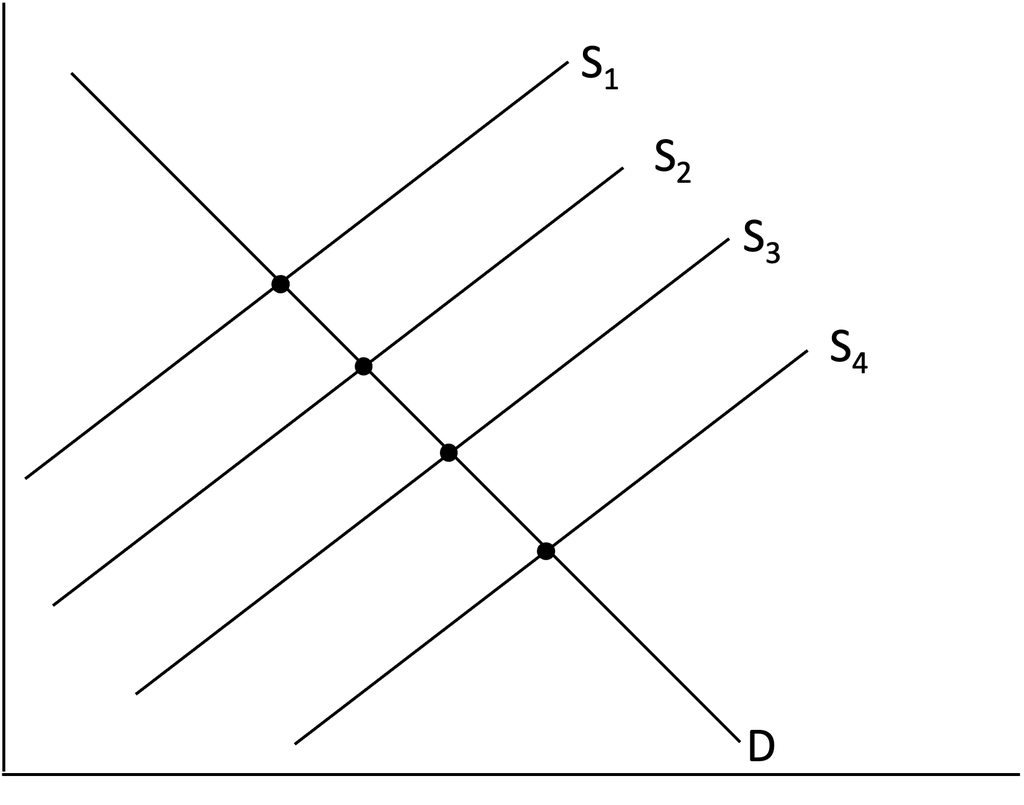

The supply shifter moves the supply curve without affecting demand, tracing out the demand curve

Our dataset includes the price of chicken feed, which presumably affects the supply of chicken, but not the demand. Let’s see what happens when we use this as an IV for the price:

```r
model.2 <- ivreg(Q ~ PCHICK + Y  |  PF + Y, data=chx)
summary(model.2)
```

```
Call:
ivreg(formula = Q ~ PCHICK + Y | PF + Y, data = chx)

Residuals:
    Min      1Q  Median      3Q     Max
-4.4966 -2.8526 -0.6623  2.5568  4.9865

Coefficients:
              Estimate Std. Error t value Pr(>|t|)
(Intercept) -12.796027   9.392025  -1.362   0.1813
PCHICK       -0.147954   0.166520  -0.889   0.3800
Y             0.003784   0.001555   2.433   0.0199 *

Diagnostic tests:
                 df1 df2 statistic p-value
Weak instruments   1  37     5.222 0.02813 *
Wu-Hausman         1  36     9.157 0.00455 **
Sargan             0  NA        NA      NA
---
Signif. codes:  0 '***' 0.001 '**' 0.01 '*' 0.05 '.' 0.1 ' ' 1

Residual standard error: 3.202 on 37 degrees of freedom
Multiple R-Squared: 0.9007, Adjusted R-squared: 0.8954
Wald test: 176.9 on 2 and 37 DF,  p-value: < 2.2e-16
```

Now the slope of the demand curve is negative, which is what we’d expect

It’s still statistically insignificant, but that might be because we’re using such a simple model with few controls

Now let’s revisit the effect of education on wages, using a different dataset

```r
card <- read_csv("card.csv")
summary(card)
```

```
       id           nearc2           nearc4            educ
 Min.   :   2   Min.   :0.0000   Min.   :0.0000   Min.   : 1.00
 1st Qu.:1276   1st Qu.:0.0000   1st Qu.:0.0000   1st Qu.:12.00
 Median :2541   Median :0.0000   Median :1.0000   Median :13.00
 Mean   :2582   Mean   :0.4409   Mean   :0.6821   Mean   :13.26
 3rd Qu.:3859   3rd Qu.:1.0000   3rd Qu.:1.0000   3rd Qu.:16.00
 Max.   :5225   Max.   :1.0000   Max.   :1.0000   Max.   :18.00

      age           fatheduc      motheduc         weight
 Min.   :24.00   Min.   : 0    Min.   : 0.00   Min.   :  75607
 1st Qu.:25.00   1st Qu.: 8    1st Qu.: 8.00   1st Qu.: 122798
 Median :28.00   Median :10    Median :12.00   Median : 365200
 Mean   :28.12   Mean   :10    Mean   :10.35   Mean   : 321185
 3rd Qu.:31.00   3rd Qu.:12    3rd Qu.:12.00   3rd Qu.: 406024
 Max.   :34.00   Max.   :18    Max.   :18.00   Max.   :1752340
                 NA's   :690   NA's   :353
    momdad14         sinmom14          step14            reg661
 Min.   :0.0000   Min.   :0.0000   Min.   :0.00000   Min.   :0.00000
 1st Qu.:1.0000   1st Qu.:0.0000   1st Qu.:0.00000   1st Qu.:0.00000
 Median :1.0000   Median :0.0000   Median :0.00000   Median :0.00000
 Mean   :0.7894   Mean   :0.1007   Mean   :0.03887   Mean   :0.04651
 3rd Qu.:1.0000   3rd Qu.:0.0000   3rd Qu.:0.00000   3rd Qu.:0.00000
 Max.   :1.0000   Max.   :1.0000   Max.   :1.00000   Max.   :1.00000

     reg662           reg663           reg664            reg665
 Min.   :0.0000   Min.   :0.0000   Min.   :0.00000   Min.   :0.0000
 1st Qu.:0.0000   1st Qu.:0.0000   1st Qu.:0.00000   1st Qu.:0.0000
 Median :0.0000   Median :0.0000   Median :0.00000   Median :0.0000
 Mean   :0.1608   Mean   :0.1957   Mean   :0.06412   Mean   :0.2083
 3rd Qu.:0.0000   3rd Qu.:0.0000   3rd Qu.:0.00000   3rd Qu.:0.0000
 Max.   :1.0000   Max.   :1.0000   Max.   :1.00000   Max.   :1.0000

     reg666            reg667         reg668            reg669
 Min.   :0.00000   Min.   :0.00   Min.   :0.00000   Min.   :0.00000
 1st Qu.:0.00000   1st Qu.:0.00   1st Qu.:0.00000   1st Qu.:0.00000
 Median :0.00000   Median :0.00   Median :0.00000   Median :0.00000
 Mean   :0.09601   Mean   :0.11   Mean   :0.02824   Mean   :0.09037
 3rd Qu.:0.00000   3rd Qu.:0.00   3rd Qu.:0.00000   3rd Qu.:0.00000
 Max.   :1.00000   Max.   :1.00   Max.   :1.00000   Max.   :1.00000

```

[output cut: 16 more lines]

```
       IQ           married         libcrd14          exper
 Min.   : 50.0   Min.   :1.000   Min.   :0.0000   Min.   : 0.000
 1st Qu.: 93.0   1st Qu.:1.000   1st Qu.:0.0000   1st Qu.: 6.000
 Median :103.0   Median :1.000   Median :1.0000   Median : 8.000
 Mean   :102.4   Mean   :2.271   Mean   :0.6743   Mean   : 8.856
 3rd Qu.:113.0   3rd Qu.:4.000   3rd Qu.:1.0000   3rd Qu.:11.000
 Max.   :149.0   Max.   :6.000   Max.   :1.0000   Max.   :23.000
 NA's   :949     NA's   :7       NA's   :13
     lwage          expersq
 Min.   :4.605   Min.   :  0.00
 1st Qu.:5.977   1st Qu.: 36.00
 Median :6.287   Median : 64.00
 Mean   :6.262   Mean   : 95.58
 3rd Qu.:6.564   3rd Qu.:121.00
 Max.   :7.785   Max.   :529.00
```

First, let’s run a basic regression on wages on education:

```r
model.1 <- lm(wage ~ educ, data=card)
summary(model.1)
```

```
Call:
lm(formula = wage ~ educ, data = card)

Residuals:
    Min      1Q  Median      3Q     Max
-576.09 -173.36  -34.12  127.82 1686.25

Coefficients:
            Estimate Std. Error t value Pr(>|t|)
(Intercept)  183.949     23.104   7.962 2.38e-15 ***
educ          29.655      1.708  17.368  < 2e-16 ***
---
Signif. codes:  0 '***' 0.001 '**' 0.01 '*' 0.05 '.' 0.1 ' ' 1

Residual standard error: 250.7 on 3008 degrees of freedom
Multiple R-squared:  0.09114,   Adjusted R-squared:  0.09084
F-statistic: 301.6 on 1 and 3008 DF,  p-value: < 2.2e-16
```

Here, the wage is measured in cents, so this implies that for every additional year of education, you make about $.3 more per hour

Of course, we’re concerned about omitted variable bias

Maybe people with more motivation or ability, who would have earned higher wages anyway, just tend to get more education

Let’s try to control for this by including controls for experience, living in an urban area, and parental education, which might be correlated with both wages and education

```r
model.2 <- lm(wage ~ educ + exper  + smsa + fatheduc + motheduc , data=card)
summary(model.2)
```

```
Call:
lm(formula = wage ~ educ + exper + smsa + fatheduc + motheduc,
    data = card)

Residuals:
    Min      1Q  Median      3Q     Max
-647.33 -148.65  -24.97  114.92 1555.55

Coefficients:
            Estimate Std. Error t value Pr(>|t|)
(Intercept) -458.236     44.546 -10.287  < 2e-16 ***
educ          46.269      2.666  17.357  < 2e-16 ***
exper         28.792      1.629  17.673  < 2e-16 ***
smsa          97.762     11.416   8.563  < 2e-16 ***
fatheduc       4.350      1.823   2.387  0.01708 *
motheduc       6.015      2.156   2.791  0.00531 **
---
Signif. codes:  0 '***' 0.001 '**' 0.01 '*' 0.05 '.' 0.1 ' ' 1

Residual standard error: 234.8 on 2214 degrees of freedom
  (790 observations deleted due to missingness)
Multiple R-squared:  0.2176,    Adjusted R-squared:  0.2158
F-statistic: 123.1 on 5 and 2214 DF,  p-value: < 2.2e-16
```

After including these controls, the coefficient on education is now *larger*

If anything, this suggests that our previous coefficient estimate might have been biased *down*

This can happen if educ is *negatively* correlated with the variables that were previously part of the error term

We’re still worried that these controls don’t completely capture the influence of important omitted variables

Let’s try to use proximity to a two- or four-year college as an IV

The theory behind this is that whether you live near a college might not be correlated with factors that affect your wage (i.e., the IV might be exogeneous)

But living near a college might make you more likely to attend (i.e., the IV might be relevant)

Before running the IV regression, let’s check the first stage to make sure the instrument is actually relevant

```r
summary(lm(educ ~ nearc2 + nearc4 + exper + smsa + fatheduc + motheduc, data=card))
```

```
Call:
lm(formula = educ ~ nearc2 + nearc4 + exper + smsa + fatheduc +
    motheduc, data = card)

Residuals:
    Min      1Q  Median      3Q     Max
-6.7760 -1.3945 -0.0774  1.2437  5.9086

Coefficients:
             Estimate Std. Error t value Pr(>|t|)
(Intercept) 13.328239   0.214187  62.227  < 2e-16 ***
nearc2      -0.003709   0.081903  -0.045  0.96389
nearc4       0.234723   0.091983   2.552  0.01078 *
exper       -0.331019   0.010913 -30.334  < 2e-16 ***
smsa         0.273393   0.096658   2.828  0.00472 **
fatheduc     0.120942   0.014333   8.438  < 2e-16 ***
motheduc     0.138223   0.016918   8.170 5.12e-16 ***
---
Signif. codes:  0 '***' 0.001 '**' 0.01 '*' 0.05 '.' 0.1 ' ' 1

Residual standard error: 1.869 on 2213 degrees of freedom
  (790 observations deleted due to missingness)
Multiple R-squared:  0.4795,    Adjusted R-squared:  0.4781
F-statistic: 339.8 on 6 and 2213 DF,  p-value: < 2.2e-16
```

The coefficient on `nearc4` is statistically significantly positive, which supports our theory that living near a four-year college increases education (`nearc2` doesn’t appear to matter)

Now let’s run the IV regression:

```r
model.3 <- ivreg(wage ~ educ + exper  + smsa + fatheduc + motheduc + smsa
                 | nearc2 + nearc4 + exper + smsa + fatheduc + motheduc,
                 data=card)
summary(model.3)
```

```
Call:
ivreg(formula = wage ~ educ + exper + smsa + fatheduc + motheduc +
    smsa | nearc2 + nearc4 + exper + smsa + fatheduc + motheduc,
    data = card)

Residuals:
    Min      1Q  Median      3Q     Max
-951.14 -187.60   -8.44  175.04 1545.57

Coefficients:
             Estimate Std. Error t value Pr(>|t|)
(Intercept) -1731.488    826.224  -2.096  0.03623 *
educ          141.214     61.561   2.294  0.02189 *
exper          60.223     20.452   2.945  0.00327 **
smsa           64.203     26.021   2.467  0.01369 *
fatheduc       -7.378      7.930  -0.930  0.35222
motheduc       -7.053      8.882  -0.794  0.42726

Diagnostic tests:
                  df1  df2 statistic p-value
Weak instruments    2 2213     3.273 0.03807 *
Wu-Hausman          1 2213     3.757 0.05270 .
Sargan              1   NA     8.971 0.00274 **
---
Signif. codes:  0 '***' 0.001 '**' 0.01 '*' 0.05 '.' 0.1 ' ' 1

Residual standard error: 294.5 on 2214 degrees of freedom
Multiple R-Squared: -0.2308,    Adjusted R-squared: -0.2335
Wald test: 41.02 on 5 and 2214 DF,  p-value: < 2.2e-16
```

The coefficient on education from the IV regression is 141

This implies that each additional year of education increases your wage by $1.41

The IV estimate is much larger than the OLS estimate

There are two possible explanations for this:

1. The OLS estimate is negatively biased
2. The IV is endogenous too (i.e., living near a college is correlated with $\varepsilon$)

Given the large difference between the OLS and IV estimates, it’s likely that the second explanation is at work here

Why might the IV be endogenous? I.e., why might living near a college be correlated with other factors that affect the wage?

One possibility is that people living near a four-year college are more likely to have parents with professional careers

These parents might pass some of their characteristics on to their kids, affecting their wages

Although our model controls for parental education, it’s possible that this doesn’t capture all of the factors that parents might pass on to their kids

This example illustrates a limitation of IV/2SLS: *it’s hard to find good instrumental variables*

Despite this, IV remains an incredibly useful tool for addressing endogeneity

Unfortunately, there is no guarantee that you’ll be able to find an IV that works for the specific question you’re interested in